# Tubakareklaamid Eesti ajalehtedes 1920-1940

Tormi Lust

2024-10-18

```r
#eemalda kõik environmentist, ainult jooksutada enda soovil
#rm(list = ls())
```

### Andmestiku sisselugemine RStudiosse.

“Tekstid_metaga” on andmestik, kus on tehtud Digilab juhendi järgi märksõnade/regulaaravaldiste otsing sõnadega “tubak, suits, sigar, pabeross”, mis on lemmatiseeritud ning filtreeritud, et näitaks vaid ajalehti aastavahemikus 1920-1939.

Digilab tööriistadest on leitud ka võimalus lehekülgede kaupa allikate leidmise jaoks ehk segmenteerimata artiklid ja reklaamid, kuid see viis mind tupikusse, kuna artiklid ja reklaamid on seal ühes pajas ja nende eraldamine nt visuaalse tuvastamisega on uus väljakutse praeguse DIGARi kasutatud OCRi parandamise nimel, mille kvaliteet jääb lehekülgedel umbes 65%-85% vahele.

Samuti on võimalik lemmatiseerimata andmeid saada, kuid sõnasageduse jms analüüsi tarbeks on kasulikum kasutada puhast lemmatiseeritud andmestikku ning ülaltoodud “tekstid_metaga” on lemmatiseeritud.

```r
tekstid_metaga <- read.csv("./andmestik/toores/tekstid_metaga.csv")
```

### “Tekstid_metaga” andmestiku aastakaupa ülevaade.

[figure not shown]

```r
tekstid_metaga %>%
  filter(LogicalSectionType == "ADVERTISEMENT") %>%
  group_by(year) %>%
  summarise(count = n_distinct(id)) %>%
  ggplot(aes(x = year, y = count)) +
  geom_col(fill = "black") +
  geom_smooth(col = "red", se = FALSE, span = 0.75) +
  labs(title = "Märksõnadega 'tubak*', 'pabeross*', 'sigar*', 'suits*' reklaamide ja kuulutuste koguhulk 1920-1939 aastatel",
       x = "Aasta",
       y = "Hulk")
```

### Alaandmestiku ehk tubakakorpuse sisse laadimine.

Piiritleme andmestikku, et sisaldaks vaid 5 päevalehte ning ainult kuulutusi, samuti piiritlen ühe reklaami tekstihulga vaid 100 tähemärgiga vasakult ja paremalt. Päris suur hulk reklaamidest ületab 1000 tähemärgi pikkuse, seega on vaja kasutada konkordantsidega andmestikku ning ma piirdusin 100 tähemärgiga märksõnadest vasakule ja paremale, mis on umbes 10-15 sõna.

```
##  [1] "id"                                 "txt"
##  [3] ".id"                                "docid"
##  [5] "LogicalSectionFirstPageID"          "attrs"
##  [7] "LogicalSectionTitle"                "LogicalSectionType"
##  [9] "LogicalSectionViewURL"              "LogicalSectionTextWordCount"
## [11] "LogicalSectionPrevLogicalSectionID" "LogicalSectionNextLogicalSectionID"
## [13] "PageOCRAccuracy"                    "MeanOCRAccuracyVol"
## [15] "date"                               "dateraw"
## [17] "year"                               "decade"
## [19] "begin"                              "end"
## [21] "context"
```

“Paevalehe_reklaamid” korpuses on nii “txt” veerg kui ka esimese leitud konkordantsi “context” veerg, kasulik on igaksjuhuks mõlemad veerud alles jätta, kuid põhifookus jääb “context” veeru kasutamisele, kuna “txt” veerus tuleb ebavajalik info juurde.

### Päevalehtede korpuse hulga ülevaade.

Valitud on päevalehtedeks Postimees, Sakala, Päevaleht ja Kaja (ja Kaja järglane Uus Eesti), eesmärgiks saada võimalikult ühtlustatud valimi reklaamidest.

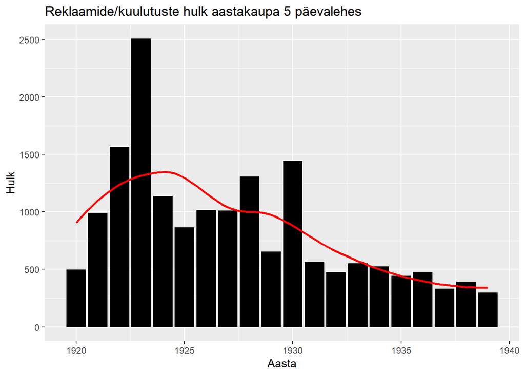

```r
paevalehe_reklaamid %>%
  filter(LogicalSectionType == "ADVERTISEMENT") %>%
  group_by(year) %>%
  summarise(count = n_distinct(id)) %>%
  ggplot(aes(x = year, y = count)) +
  geom_col(fill = "black") +
  geom_smooth(col = "red", se = FALSE, span = 0.75) +
  labs(title = "Reklaamide/kuulutuste hulk aastakaupa 5 päevalehes",
       x = "Aasta",
       y = "Hulk")
```

```r
#Loess'iga ja usalduspiiriga geom_smooth(col = "red", se = TRUE, span = 0.75) +
#Linear on (method = "lm", col = "red", se = FALSE)
```

Loome sõnasagedusefunktsiooni, kuna kasutame korduvalt seda erinevate sektorite analüüsil. Esmalt laeme sisse stoppsõnad, siis teeme sõnasageduse, kus on vaid sõnad, mis algavad alates 3’st tähest ning “w” täht on asendatud “v” tähega. Numbrid samuti eemaldatud.

### Vaatame, milline näeb välja 5 päevalehe tubakareklaamide sõnasagedused 1920-1940 aastate vältel.

Visualiseerime sõnasageduse. Sõnad on lemmatiseeritud, stoppsõnad on sagedusest ära võetud ning tabelit on piiratud alates 3-tähelistest sõnadest.

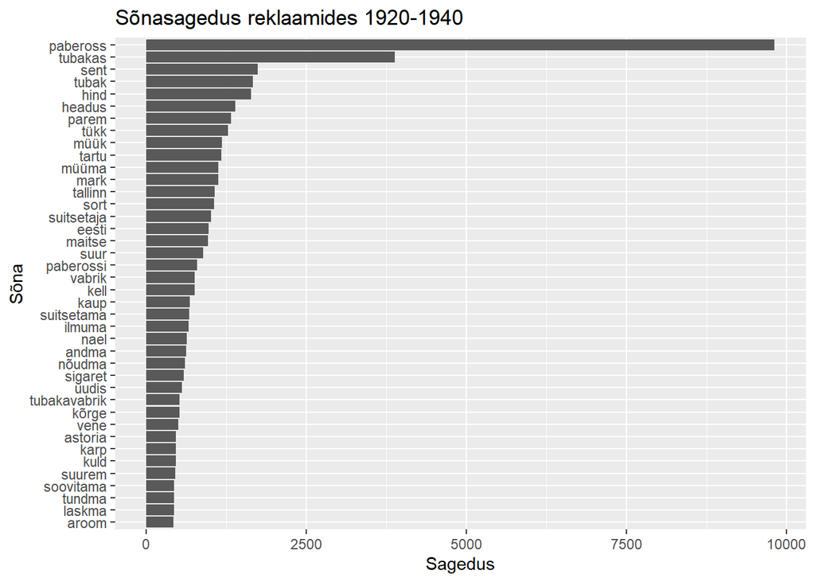

```r
ggplot(paevalehe_sonasagedus[1:40, ], aes(x = reorder(word, n), y = n)) +
  geom_col() +
  coord_flip() +
  labs(x = "Sõna", y = "Sagedus", title = "Sõnasagedus reklaamides 1920-1940")
```

Eemaldame peamised otsisõnad, sest need ei aita märgata rahvuslikke sõnu.

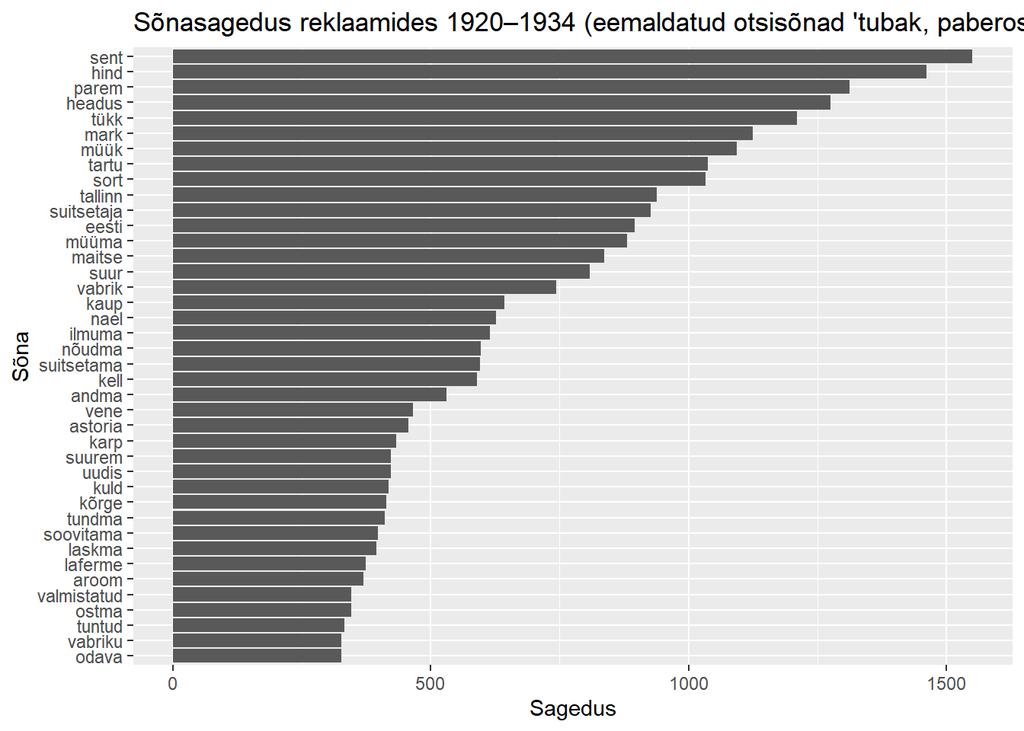

```r
# 1) Sõnasagedus 1920–1934 – eemaldame tubak*, pabeross*, sigar*
sonas_20_34 <- paevalehe_reklaamid %>%
  filter(LogicalSectionType == "ADVERTISEMENT",
         year >= 1920,
         year <= 1934) %>%
  sonasagedusefunktsioon() %>%
  filter(!str_detect(word,
                     regex("^(tubak.*|pabeross.*|sigar.*)$",
                           ignore_case = TRUE)))

# 2) Sõnasagedus 1934–1940 – sama puhastus
sonas_34_40 <- paevalehe_reklaamid %>%
  filter(LogicalSectionType == "ADVERTISEMENT",
         year >= 1934,
         year <= 1940) %>%
  sonasagedusefunktsioon() %>%
  filter(!str_detect(word,
                     regex("^(tubak.*|pabeross.*|sigar.*)$",
                           ignore_case = TRUE)))

ggplot(sonas_20_34[1:40, ], aes(x = reorder(word, n), y = n)) +
  geom_col() +
  coord_flip() +
  labs(
    x = "Sõna",
    y = "Sagedus",
    title = "Sõnasagedus reklaamides 1920–1934 (eemaldatud otsisõnad 'tubak, pabeross, sigar')"
  )
```

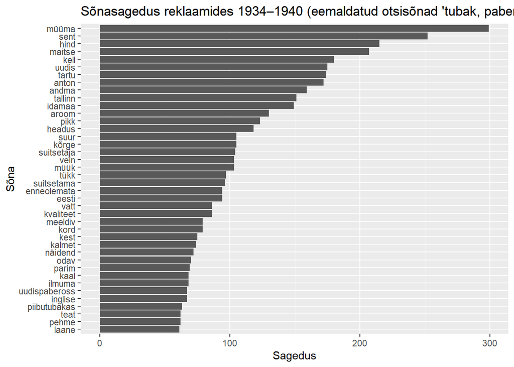

```r
ggplot(sonas_34_40[1:40, ], aes(x = reorder(word, n), y = n)) +
  geom_col() +
  coord_flip() +
  labs(
    x = "Sõna",
    y = "Sagedus",
    title = "Sõnasagedus reklaamides 1934–1940 (eemaldatud otsisõnad 'tubak, pabeross, sigar')"
  )
```

Võiks öelda sõnasageduse põhjal, et andmestik on isegi rohkem välismaid mainivate sõnadega vaikival ajastul, kui varasemalt.